# STAT/MATH 495: Problem Set 06

Albert Y. Kim and Andrew Kim

2017-10-17

# Collaboration

Please indicate who you collaborated with on this assignment:

# Setup

Define truth, which again we know for the purposes of this assignment, but in practice we won’t:

- the true function f(x) i.e. the signal
- the true epsilon i.e. the noise, which in this case is Normal$(0, \mbox{sd} = \sigma)$. Hence the standard deviation $\sigma$ determines the amount of noise.

```r
f <- function(x) {
  x^2
}
sigma <- 0.3
```

This is the target point we’ll be trying to predict: $(0.95, f(0.95)) = (0.95, 0.95^2) = (0.95, 0.9025)$, Thus, the test set is just `x=0.95`

```r
x0 <- 0.95
test_set <- data_frame(x=x0)
```

This function generates a random sample of size $n$; think of this as a “get new data” function. Random in terms of both:

- (New) the predictor x (uniform on [0,1])
- the amount of noise $\epsilon$

```r
generate_sample <- function(f, n, sigma) {
  sample <- data_frame(
    x = runif(n = n, min = 0, max = 1),
    f_x = f(x),
    epsilon = rnorm(n = n, mean = 0, sd = sigma),
    y = f_x + epsilon
  )
  # Recall: We don't observe f(x) and epsilon, just (x, y)
  sample <- sample %>%
    select(x, y)

  return(sample)
}
```

Define

- The number $n$ of observations $(x_i, y_i)$ in each sample. In the handout, $n=100$ to keep plots uncrowded. Here we boost to $n=500$
- Number of samples of size $n$ to consider

```r
n <- 500
n_samples <- 10000
```

# Computation

## Get fitted/predicted values $\widehat{f}(0.95)$

First, let’s

1. Generate a new training set of observations $(x_i, y_i)$ for $i=1, \ldots, n= 500$
2. Based on the above training set, fit
   1. a spline model $\widehat{y} = \widehat{f}_{2}(x)$ using degrees of freedom $df=2$
   2. a spline model $\widehat{y} = \widehat{f}_{99}(x)$ using degrees of freedom $df=99$
3. Use these models to predict the value of $f(0.95) = 0.95^2$ by computing
   1. $\widehat{y} = \widehat{f}_{2}(0.95)$
   2. $\widehat{y} = \widehat{f}_{99}(0.95)$

Repeat the above 10000 times

```r
# Store predicted values here
y_hat_df_2 <- rep(0, n_samples)
y_hat_df_99 <- rep(0, n_samples)

for(i in 1:n_samples) {
  # 1. Sample a new instance of training data (x, y)
  train_set <- generate_sample(f, n, sigma)

  # 2.a) Fit df=2 model & predict on test set
  df_2_model <- smooth.spline(x=train_set$x, y=train_set$y, df=2)
  y_hat_df_2[i] <- predict(df_2_model, x=test_set$x)$y

  # 3.a) Fit df=99 model & predict on test set
  df_99_model <- smooth.spline(x=train_set$x, y=train_set$y, df=99)
  y_hat_df_99[i] <- predict(df_99_model, x=test_set$x)$y
}
```

Let’s visualize

- A histogram of the 10^{4} $\widehat{f}_{2}(0.95)$
- A histogram of the 10^{4} $\widehat{f}_{99}(0.95)$
- A red line indicating the true $f(0.95) = 0.95^2 = 0.9025$.

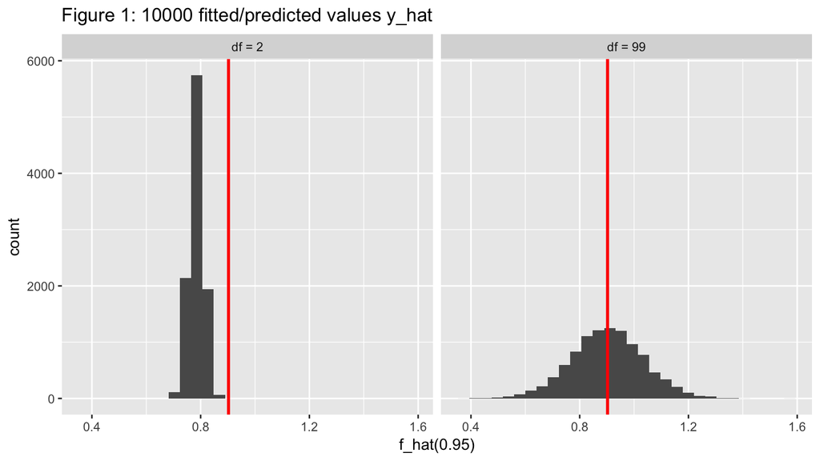

We observe just as from the [handout from Lec 2.7](https://rudeboybert.github.io/STAT495/static/generate_splines_bias_variance_handout/plots.pdf) that for

- $df=2$ we have lower variance (AKA lower standard error) and higher bias
- $df=99$ we have higher variance and lower bias (almost none in fact)

## Creating $y$’s

We now take our 10000 instances of $\widehat{f}_{2}(0.95)$ and $\widehat{f}_{99}(0.95)$ and evaluate the MSE. This necessitates 10000 values of $y$. What is $y$? One source of confusion *everyone* encounters when doing this exercise (even I did) was:

- $\widehat{y} = \widehat{f}(x)$
- $y \neq f(0.95)$. Rather $y = f(x) + \epsilon$

Note that $y$’s incorporate *the unsystematic error term* $\epsilon$. In most real-life cases, we won’t know the mechanism that generates these terms. In this exercise however, we do:

$$\epsilon \sim \mbox{Normal}\left(0, \sigma = 0.3 \right)$$

We can’t use the `generate_sample()` function above as this generates observations $(x,y)$ for many different $x$’s. However, we only want $y$’s for $x=0.95$. So let’s manually construct them!

```r
# First the error component...
epsilon <- rnorm(n = n_samples, mean = 0, sd = sigma)
# Then the signal component...
x <- rep(0.95, times = n_samples)
f_x <- f(x)
# Now put them together...
y <- f_x + epsilon
```

Let’s put all these vectors together into a single data frame!

```r
results <- data_frame(
  x = rep(x0, n_samples),
  f_x = f(x),
  eps = rnorm(n = n_samples, mean = 0, sd = sigma),
  y = f_x + eps
)
```

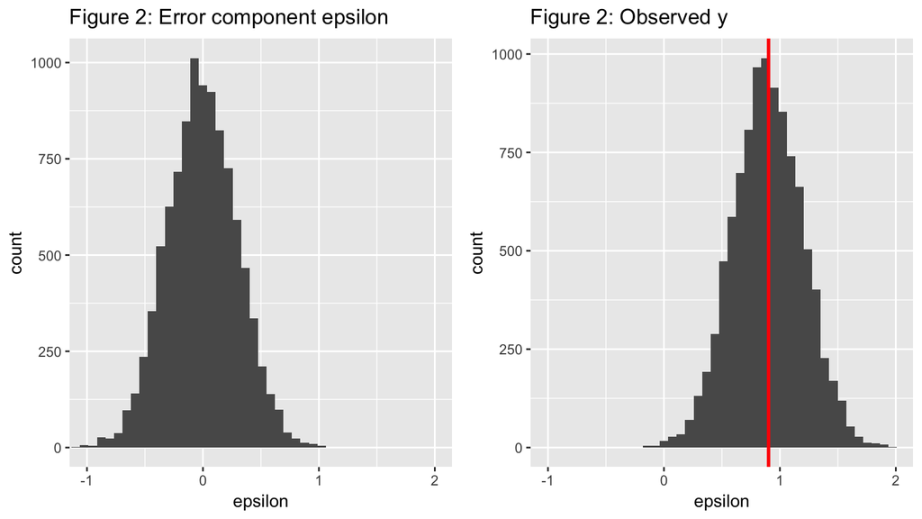

## Evaluate MSE and breakdown

Let’s now tack on our fitted values:

```r
results <- results %>%
  mutate(
    y_hat_df_2 = y_hat_df_2,
    y_hat_df_99 = y_hat_df_99
  )
```

Let’s show bias^2/variance/irreducible error breakdown for $df=2$

```r
results %>%
  mutate(y_hat = y_hat_df_2) %>%
  summarise(
    MSE = mean((y-y_hat)^2),
    bias_squared = mean((f_x-y_hat))^2,
    var = var(y_hat)
  ) %>%
  mutate(
    irreducible = sigma^2,
    sum = bias_squared + var + irreducible
    ) %>%
  kable(digits = 4)
```

| MSE | bias_squared | var | irreducible | sum |
| --- | --- | --- | --- | --- |
| 0.1033 | 0.0138 | 7e-04 | 0.09 | 0.1045 |

Let’s show bias^2/variance/irreducible error breakdown for $df=99$

```r
results %>%
  mutate(y_hat = y_hat_df_99) %>%
  summarise(
    MSE = mean((y-y_hat)^2),
    bias_squared = mean((f_x-y_hat))^2,
    var = var(y_hat)
  ) %>%
  mutate(
    irreducible = sigma^2,
    sum = bias_squared + var + irreducible
  ) %>%
  kable(digits = 4)
```

| MSE | bias_squared | var | irreducible | sum |
| --- | --- | --- | --- | --- |
| 0.1072 | 0 | 0.0178 | 0.09 | 0.1078 |

# Analysis

**Questions**:

1. Based on the topics covered in Lec 2.7, name one possible “sanity check” for your results. Name another if you can.
2. In **two** sentences or less, give a rough sketch of what the procedure would be to get the breakdown of
   $$\mbox{MSE}\left[\widehat{f}(x)\right]$$
   for *all* $x$ in this example, and not just for
   $$\mbox{MSE}\left[\widehat{f}(x_0)\right]
   = \mbox{MSE}\left[\widehat{f}(0.95)\right]$$
   .
3. Which of the two models would you choose for predicting the point of interest and why?

**Answers**:

Chalk talk 2.8 on Thu 11/2.